# Practical 1 - Logistic Regression

Stephan Peischel

Interfaculty Bioinformatics Unit, University of Bern

04.06.2024

Logistic regression is a statistical method used for binary classification problems. In this tutorial, we will fit a logistic regression model to a dataset (pp_train) on the survival of premature babies and visualize the predicted probabilities along with the observed data points.

The dataset includes the following variables:

```
- Survival: Survival status of the baby (0 = did not survive, 1 = survived)

- Weight: Birth weight of the baby (in grams)

- Age: Gestational age of the baby (in weeks)

- X1.Apgar: Apgar score at 1 minute after birth

- X5.Apgar: Apgar score at 5 minutes after birth

- pH: Blood pH level of the baby
```

```r
knitr::opts_chunk$set(echo = TRUE)
library(dplyr)
```

```r
library(ggplot2)
library(ggcorrplot)
library(cowplot)
library(caret)
```

## Data Exploration

First, let’s load and explore the dataset:

```r
df <- read.table("data/baby.dat", header = TRUE)
```

View the first few rows of the dataset:

```r
head(df)
```

```
##   Survival Weight Age X1.Apgar X5.Apgar   pH
## 1        1   1350  32        4        7 7.25
## 2        0    725  27        5        6 7.36
## 3        0   1090  27        5        7 7.42
## 4        0   1300  24        9        9 7.37
## 5        0   1200  31        5        5 7.35
## 6        0    590  22        9        9 7.37
```

Summary statistics:

```r
summary(df)
```

```
##     Survival          Weight          Age           X1.Apgar
##  Min.   :0.0000   Min.   : 540   Min.   :20.00   Min.   :0.000
##  1st Qu.:0.0000   1st Qu.: 860   1st Qu.:26.00   1st Qu.:3.000
##  Median :1.0000   Median :1070   Median :28.00   Median :5.000
##  Mean   :0.6518   Mean   :1075   Mean   :28.04   Mean   :4.652
##  3rd Qu.:1.0000   3rd Qu.:1320   3rd Qu.:30.00   3rd Qu.:6.000
##  Max.   :1.0000   Max.   :1500   Max.   :37.00   Max.   :9.000
##     X5.Apgar            pH
##  Min.   : 0.000   Min.   :6.830
##  1st Qu.: 5.000   1st Qu.:7.270
##  Median : 6.000   Median :7.340
##  Mean   : 6.194   Mean   :7.323
##  3rd Qu.: 7.000   3rd Qu.:7.380
##  Max.   :10.000   Max.   :7.600
```

Check the structure of the dataset:

```r
str(df)
```

```
## 'data.frame':    247 obs. of  6 variables:
##  $ Survival: int  1 0 0 0 0 0 1 1 0 1 ...
##  $ Weight  : int  1350 725 1090 1300 1200 590 1500 1360 600 1410 ...
##  $ Age     : int  32 27 27 24 31 22 32 29 24 30 ...
##  $ X1.Apgar: int  4 5 5 9 5 9 9 9 4 4 ...
##  $ X5.Apgar: int  7 6 7 9 5 9 9 9 4 5 ...
##  $ pH      : num  7.25 7.36 7.42 7.37 7.35 7.37 7.29 7.44 7.27 7.35 ...
```

Plot the distribution of survival status:

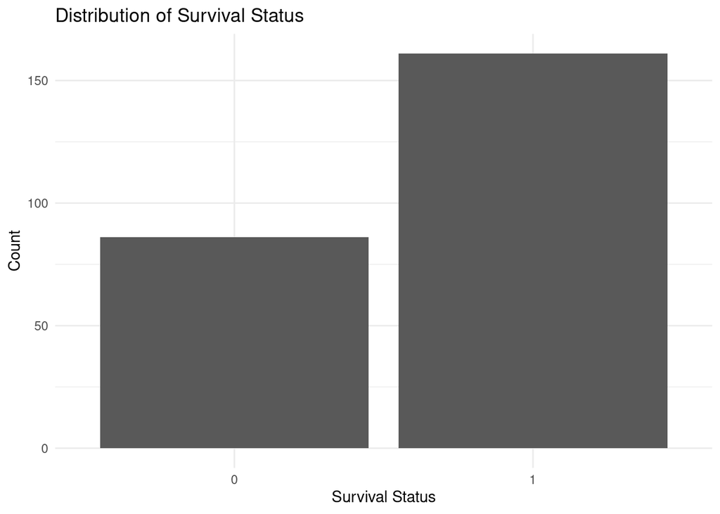

```r
ggplot(df, aes(x = factor(Survival))) +
  geom_bar() +
  labs(x = "Survival Status", y = "Count", title = "Distribution of Survival Status") +
  theme_minimal()
```

Visualize the distribution of each variable grouped by survival status:

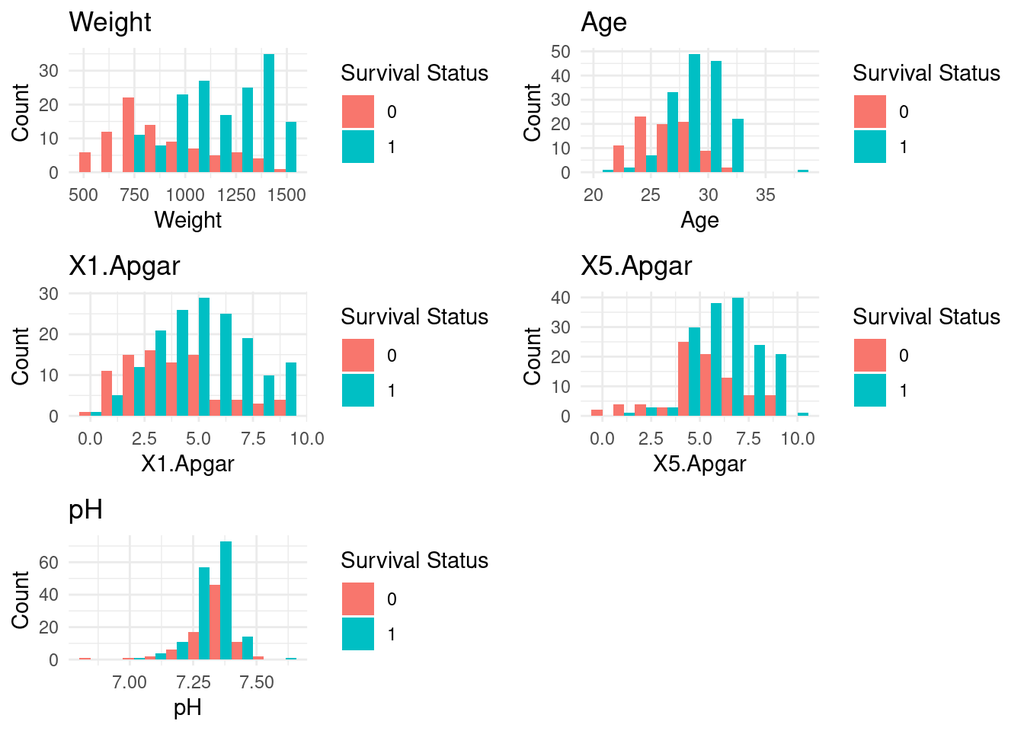

```r
variables <- colnames(df)[2:length(colnames(df))]
plot_list <- list()

for (var in variables) {
  p <- ggplot(df, aes(x = !!sym(var), fill = factor(Survival))) +
    geom_histogram(position = "dodge", bins = 10) +
    labs(x = var, y = "Count", fill = "Survival Status", title = var) +
    theme_minimal()
  plot_list[[var]] <- p
}

plot_grid(plotlist = plot_list, nrow = 3)
```

Visualize the box plots of each variable grouped by survival status:

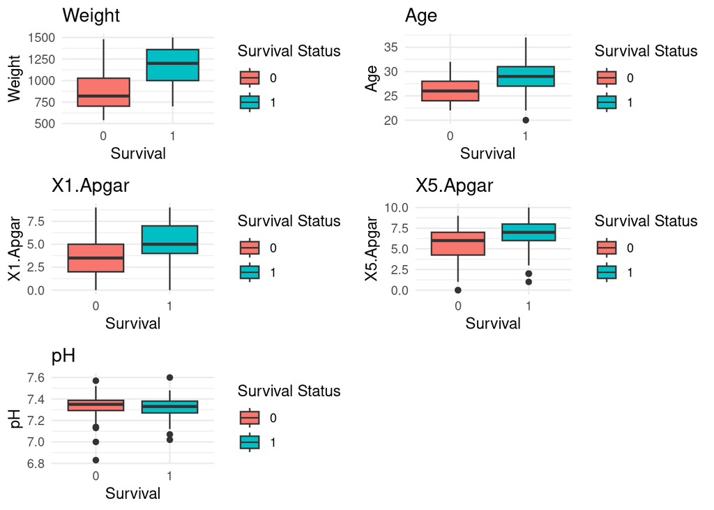

```r
plot_list <- list()

for (var in variables) {
  p <- ggplot(df, aes(y = !!sym(var), fill = factor(Survival), x = factor(Survival))) +
    geom_boxplot() +
    labs(x = "Survival", y = var, fill = "Survival Status", title = var) +
    theme_minimal()
  plot_list[[var]] <- p
}

plot_grid(plotlist = plot_list, nrow = 3)
```

## Feature Engineering & Data Splitting

For the logistic regression, we split the data into test (30%) and train (70%) sets.

```r
df <- df %>%
  rename(labels = Survival) %>%
  mutate(labels = factor(labels))
levels(df$labels) <- c("not surviving", "surviving")

trn_indx <- createDataPartition(df$labels, p = 0.7, list = FALSE, times = 1) %>%
  as.numeric()
tst_indx <- which(!(seq_len(nrow(df)) %in% trn_indx))

train <- df[trn_indx, ]
test <- df[tst_indx, ]

table(train$labels)
```

```
##
## not surviving     surviving
##            61           113
```

```r
table(test$labels)
```

```
##
## not surviving     surviving
##            25            48
```

It is important to preprocess the data after splitting the data into test and train sets to avoid information leakage.

```r
(preproc <- preProcess(train, method = c("center", "scale")))
```

```
## Created from 174 samples and 6 variables
##
## Pre-processing:
##   - centered (5)
##   - ignored (1)
##   - scaled (5)
```

```r
pp_train <- predict(preproc, train)

(preproc <- preProcess(test, method = c("center", "scale")))
```

```
## Created from 73 samples and 6 variables
##
## Pre-processing:
##   - centered (5)
##   - ignored (1)
##   - scaled (5)
```

```r
pp_test <- predict(preproc, test)
```

## Fitting a Logistic Regression

Fit the logistic regression model:

```r
# Fit the logistic regression model
babies.fit <- glm(labels ~ ., data = pp_train, family = "binomial")
summary(babies.fit)
```

```
##
## Call:
## glm(formula = labels ~ ., family = "binomial", data = pp_train)
##
## Coefficients:
##             Estimate Std. Error z value Pr(>|z|)
## (Intercept)   0.9342     0.2159   4.327 1.51e-05 ***
## Weight        1.2719     0.2859   4.448 8.67e-06 ***
## Age           0.2174     0.2507   0.867    0.386
## X1.Apgar      0.2991     0.3156   0.948    0.343
## X5.Apgar      0.2061     0.2991   0.689    0.491
## pH           -0.1885     0.2078  -0.907    0.364
## ---
## Signif. codes:  0 '***' 0.001 '**' 0.01 '*' 0.05 '.' 0.1 ' ' 1
##
## (Dispersion parameter for binomial family taken to be 1)
##
##     Null deviance: 225.43  on 173  degrees of freedom
## Residual deviance: 158.10  on 168  degrees of freedom
## AIC: 170.1
##
## Number of Fisher Scoring iterations: 5
```

Create predicted probabilities:

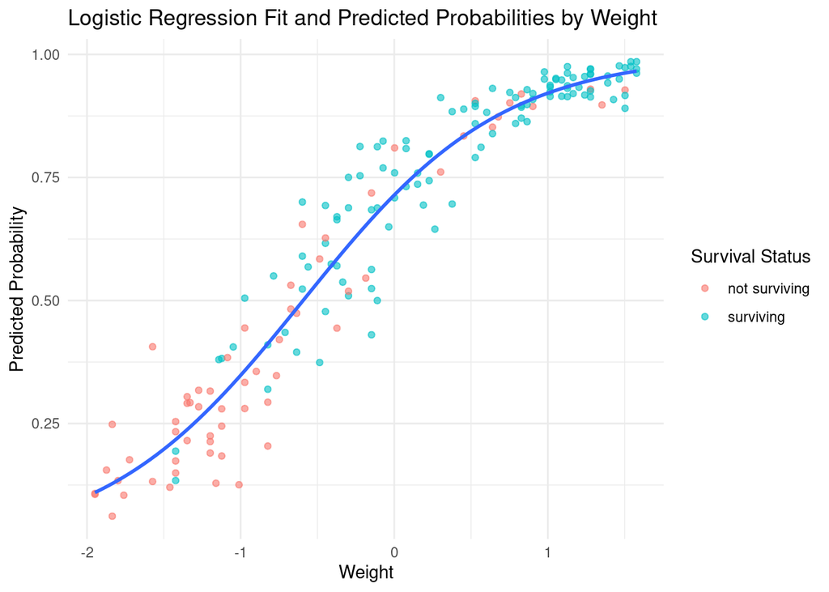

```r
# Create a data frame with the predicted probabilities
pp_train$predicted_prob <- predict(babies.fit, type = "response")

# Plot the observed data points and the fitted logistic regression line
ggplot(pp_train, aes(x = Weight, y = predicted_prob)) +
  geom_point(aes(color = factor(labels)), alpha = 0.6) +
  geom_smooth(method = "glm", method.args = list(family = "binomial"), se = FALSE) +
  labs(x = "Weight", y = "Predicted Probability", color = "Survival Status",
       title = "Logistic Regression Fit and Predicted Probabilities by Weight") +
  theme_minimal()
```

to evaluate the performance of the logistic regression model, we create a confusion matrix:

```r
# Create predicted labels based on a threshold of 0.5
pp_train$predicted_label <- ifelse(pp_train$predicted_prob > 0.5, 1, 0)

# Create a confusion matrix
conf_matrix <- table(pp_train$predicted_label, pp_train$labels)
print(conf_matrix)
```

```
##
##     not surviving surviving
##   0            42        13
##   1            19       100
```